# Cleaning excel file

# Load libraries

First, we load required libraries for importing and data cleaning

```r
library(readxl)
library(tidyverse)
library(openxlsx)
library(dplyr)
library(here)
library(janitor)
library(skimr)
library(stringr)
library(ggplot2)
```

# Import file from excel file

We import two sheets from excel file. Sheet 8.Effects, and sheet 7. Evaluations.

```r
ruta_file <- here("data", "effect-sizes-raw.xlsx")
effects <- read_excel(ruta_file, sheet = "8. Effects", col_names = TRUE,
                      na = c("","-", "missing", "missings")) %>%
  clean_names() %>%
  rename("outcome_type" = outcome_type_10,
         "outcome_description" = outcome_type_11 )
#importamos la hoja 7. Evaluations el excel
evaluations <- read_excel(ruta_file, sheet = "7. Evaluations", col_names = TRUE,
                          na = c("","-", "missing", "missings")) %>%
  clean_names()
```

```r
effects %>%
  filter(outcome_type == 1) %>%
  distinct(evaluation_id)
```

| evaluation_id |
| --- |
| Acero 2009 |
| Acevedo 2017 i |
| Acevedo 2017 ii |
| Adoho 2014 i |
| Alcid 2014 |
| Alvares de Azevedo 2013 i |
| Alvares de Azevedo 2013 ii |
| Attanasio 2011 |
| Schochet 2008 |
| Bausch 2016 |

[output cut: 62 more lines]

# Correct type of variables

Select only required variables from evaluations sheet, and convert categorical variables to factor

```r
evaluations_filter <- evaluations %>%
  select(paper_id, evaluation_id,
         skills = ends_with("technical_soft_job_readiness"),
         training = ends_with("class_internship"),
         youth,
         implementer,
         where_internship = starts_with("where_is_the_internship"),
         where_class = starts_with("where_is_the_classroom"),
         length_class_hours = ends_with("classroom_hours"),
         length_class_months = ends_with("classroom_months"),
         length_internship_hours = ends_with("internship_hours"),
         length_internship_months = ends_with("internship_months"),
         lac = ends_with("lac") ,
         decision=type_of_decision ,
         vulnerable=vulnerable_yes_no,
         vulnerability_type,
         holistic) %>%
  mutate_at(c("skills","training","where_internship","where_class",
              "youth","implementer"),
            .fun = parse_factor, levels = NULL)

evaluations_filter <- evaluations_filter %>%
  mutate(implementer=recode(implementer, government="Government"))

skim(evaluations_filter)
```

```
Skim summary statistics
 n obs: 106
 n variables: 17

-- Variable type:character -----------------------------------------------------
           variable missing complete   n min max empty n_unique
           decision       1      105 106   1  17     0        4
      evaluation_id       0      106 106   8  26     0       85
           holistic       0      106 106   6  12     0        4
                lac       0      106 106   2   3     0        2
           paper_id       0      106 106   8  25     0       87
 vulnerability_type      46       60 106   5 125     0       18
         vulnerable       0      106 106   2  13     0        3

-- Variable type:factor --------------------------------------------------------
         variable missing complete   n n_unique                         top_counts ordered
      implementer       0      106 106        5   Gov: 68, NGO: 31, Res: 4, Pri: 2   FALSE
           skills       0      106 106        5 tec: 46, bot: 20, tec: 17, sof: 15   FALSE
         training       0      106 106        5    cla: 61, bot: 33, NA: 9, som: 2   FALSE
      where_class       0      106 106        4  pri: 68, pub: 14, NA: 13, pub: 11   FALSE
 where_internship       0      106 106        3            NA: 73, pri: 29, pri: 4   FALSE
            youth       0      106 106        4   bot: 68, les: 30, mor: 6, men: 2   FALSE

-- Variable type:numeric -------------------------------------------------------
                 variable missing complete   n   mean     sd    p0 p25 p50 p75 p100     hist
       length_class_hours      51       55 106 330.53 370.01  3.25  80 180 400 1200 ▇▃▂▁▁▁▁▂
      length_class_months      31       75 106   6.82   5.68  0.25   3   6   8   24 ▇▇▅▁▁▂▁▁
  length_internship_hours      97        9 106 258    142.79 80    128 240 360  480 ▇▁▁▇▁▂▁▅
 length_internship_months      79       27 106   4.72   5.11  1.2    2   3   4   24 ▇▁▁▁▁▁▁▁
```

Select only required variables from effects sheet, and convert categorical variables to factor

```r
effects_filter <- effects %>%
  select(paper_id,
         evaluation_id:population,
         months_of_delay:outcome_description,
         n_total = n, nt:se,
         t,
         p_value,
         se_calculated,
         starts_with("smd"),
         starts_with("vd")) %>%
  mutate(vd = if_else(is.na(vd_mean), vd_regress, vd_mean),
         gender = recode_factor(gender, Female = "female",
                                Pooled = "pooled", Male = "male") ) %>%
  select(-starts_with("vd_"))

skim(effects_filter)
```

```
Skim summary statistics
 n obs: 1211
 n variables: 19

-- Variable type:character -----------------------------------------------------
            variable missing complete    n min max empty n_unique
           age_group     973      238 1211   3  12     0       30
       evaluation_id       0     1211 1211   8  26     0       84
     months_of_delay     104     1107 1211   1   4     0       61
 outcome_description       0     1211 1211   4 347     0      167
            paper_id       0     1211 1211   8  25     0       86
          population      13     1198 1211   5  66     0       65

-- Variable type:factor --------------------------------------------------------
 variable missing complete    n n_unique                          top_counts ordered
   gender       0     1211 1211        3 poo: 685, fem: 291, mal: 235, NA: 0   FALSE

-- Variable type:numeric -------------------------------------------------------
            variable missing complete    n      mean         sd          p0       p25       p50       p75       p100     hist
                beta       0     1211 1211  924.96    4947.01   -9836        -0.002      0.063    57.25    70861     ▇▁▁▁▁▁▁▁
           effect_id       0     1211 1211   17.83      18.12       1         4         11        25          82     ▇▃▂▁▁▁▁▁
             n_total      12     1199 1211 8296.46   21113.8      115       751.5     2088      5228      178636     ▇▁▁▁▁▁▁▁
                  nc      12     1199 1211 4828.73   15281.47      45.25    341        856      2020      150308     ▇▁▁▁▁▁▁▁
                  nt      12     1199 1211 3242.31    7261.71      38       375       1087      2995       80840     ▇▁▁▁▁▁▁▁
        outcome_type       0     1211 1211    2.29       1.58       1         1          2         2           8     ▇▇▁▁▁▁▁▁
             p_value     740      471 1211    0.34       0.27       0         0.05       0.5       0.5         0.98  ▇▁▁▁▇▁▁▁
                  se     546      665 1211  451.75    2205.42       0         0.032      0.12     58.02    23355     ▇▁▁▁▁▁▁▁
       se_calculated      14     1197 1211  639.22    5007.04       0         0.029      0.2     147       82027.73  ▇▁▁▁▁▁▁▁
 smd_treated_control     513      698 1211    0.057      0.13      -0.65     -0.0032     0.051     0.12        0.77  ▁▁▁▇▆▁▁▁
                   t     707      504 1211    1.22       0.89      -1.64      0.67       0.68      1.96        3.91  ▁▁▂▇▂▂▃▁
                  vd     513      698 1211    0.0044     0.0062     2.5e-05   0.00086    0.0022    0.0058      0.045 ▇▂▁▁▁▁▁▁
```

Somehow, `months_of_delay` is categorized as character, let’s explore it:

```r
effects_filter %>%
  filter(!is.na(months_of_delay)) %>%
  select(paper_id, months_of_delay) %>%
  mutate(months_numeric = as.numeric(months_of_delay)) %>%
  filter(is.na(months_numeric))
```

```
NAs introduced by coercion
```

| paper_id | months_of_delay | months_numeric |
| --- | --- | --- |
| Chakravarty 2016 ii | 9-11 | NA |
| Chakravarty 2016 ii | 9-11 | NA |
| Chakravarty 2016 ii | 9-11 | NA |
| Chakravarty 2016 ii | 9-11 | NA |
| Chakravarty 2016 ii | 9-11 | NA |
| Chakravarty 2016 ii | 9-11 | NA |
| Chakravarty 2016 ii | 9-11 | NA |
| Chakravarty 2016 ii | 9-11 | NA |
| Chakravarty 2016 ii | 9-11 | NA |
| Chakravarty 2016 ii | 9-11 | NA |

[output cut: 7 more lines]

The problem is how Chakravarty 2016 ii and Dyke 2006 i coded its months of delay. Let’s change it:

```r
effects_filter <- effects_filter %>%
  mutate(months_of_delay = replace(months_of_delay, months_of_delay == "9-11", 11),
         months_of_delay = replace(months_of_delay, months_of_delay == "0-4", 4),
         months_of_delay = as.numeric(months_of_delay))

effects_filter$months_of_delay %>% skim()
```

```
Skim summary statistics

-- Variable type:numeric -------------------------------------------------------
 variable missing complete    n  mean    sd p0 p25  p50 p75 p100     hist
        .     104     1107 1211 26.61 23.13 -6  12 19.5  36  156 ▇▆▃▂▁▁▁▁
```

Now, we have outcomes reported between -6 to 156 months (13 years).

#Merge datasets (two sheets) We merge the two previous datasets by paper_id and evaluation_id:

```r
effects_evaluations <- effects_filter %>%
  left_join(evaluations_filter, by= c("paper_id","evaluation_id"))

skim(effects_evaluations)
```

```
Skim summary statistics
 n obs: 1271
 n variables: 34

-- Variable type:character -----------------------------------------------------
            variable missing complete    n min max empty n_unique
           age_group    1033      238 1271   3  12     0       30
            decision     123     1148 1271   1  17     0        4
       evaluation_id       0     1271 1271   8  26     0       84
            holistic     105     1166 1271   6  12     0        4
                 lac     105     1166 1271   2   3     0        2
 outcome_description       0     1271 1271   4 347     0      167
            paper_id       0     1271 1271   8  25     0       86
          population      13     1258 1271   5  66     0       65
  vulnerability_type     579      692 1271   5 125     0       18
          vulnerable     105     1166 1271   2  13     0        3

-- Variable type:factor --------------------------------------------------------
         variable missing complete    n n_unique                            top_counts ordered
           gender       0     1271 1271        3   poo: 745, fem: 291, mal: 235, NA: 0   FALSE
      implementer     105     1166 1271        5  Gov: 937, NGO: 197, NA: 105, Res: 17   FALSE
           skills     105     1166 1271        5 tec: 617, bot: 229, NA: 181, tec: 152   FALSE
         training     105     1166 1271        5  cla: 787, bot: 273, NA: 185, som: 21   FALSE
      where_class     105     1166 1271        4 pri: 640, NA: 277, pub: 227, pub: 127   FALSE
 where_internship     105     1166 1271        3            NA: 957, pri: 298, pri: 16   FALSE
            youth     105     1166 1271        4  bot: 670, les: 417, NA: 105, mor: 75   FALSE

-- Variable type:numeric -------------------------------------------------------
                 variable missing complete    n      mean        sd          p0       p25       p50       p75       p100     hist
                     beta       0     1271 1271  907.8     4837.29  -9836        -0.001      0.067    60.22    70861     ▇▁▁▁▁▁▁▁
                effect_id       0     1271 1271   17.48      17.8       1         4         11        24          82     ▇▃▁▁▁▁▁▁
       length_class_hours     648      623 1271  440.91     387.22      3.25    150        360       700        1200     ▇▃▃▂▂▁▁▃
      length_class_months     489      782 1271    5.67       4.01      0.25      3          5         8          24     ▇▇▅▁▁▁▁▁
  length_internship_hours    1192       79 1271  226.03     114.75     80       128        240       240         480     ▇▁▁▆▁▃▁▂
 length_internship_months     962      309 1271    4.24       4.45      1.2       3          3         3          24     ▇▁▁▁▁▁▁▁
          months_of_delay     164     1107 1271   26.61      23.13     -6        12         19.5      36         156     ▇▆▃▂▁▁▁▁
                  n_total      12     1259 1271 7928.01   20669.94    115       697       1880      4819.5    178636     ▇▁▁▁▁▁▁▁
                       nc      12     1259 1271 4611.69   14944.15     45.25    328.75     715.09   1987      150308     ▇▁▁▁▁▁▁▁
                       nt      12     1259 1271 3101.64    7114.3      38       349        986      2948       80840     ▇▁▁▁▁▁▁▁
             outcome_type       0     1271 1271    2.31       1.59      1         1          2         2           8     ▇▇▁▁▁▂▁▁
                  p_value     740      531 1271    0.35       0.26      0         0.05       0.5       0.5         0.98  ▆▁▁▁▇▁▁▁
                       se     606      665 1271  451.75    2205.42      0         0.032      0.12     58.02    23355     ▇▁▁▁▁▁▁▁
            se_calculated      14     1257 1271  635.8     4891.64      0         0.03       0.37    159.27    82027.73  ▇▁▁▁▁▁▁▁
      smd_treated_control     525      746 1271    0.058      0.13     -0.65     -8.5e-05    0.051     0.12        0.77  ▁▁▁▇▆▁▁▁
                        t     707      564 1271    1.2        0.87     -1.64      0.67       0.68      1.96        3.91  ▁▁▂▇▂▂▂▁
                       vd     525      746 1271    0.0046     0.006     2.5e-05   0.00088    0.0026    0.0059      0.045 ▇▂▁▁▁▁▁▁
```

Defining when an intervention is long or short depending on how many months in total there were

First, we assume that 1 month of classes or internship was equivalent to 80 hours. We find this value is close to the average in the data available:

```r
evaluations_filter %>%
  mutate(hora_promedio_class = length_class_hours / length_class_months,
         hora_promedio_internship = length_internship_hours / length_internship_months) %>%
  summarise(mean_horas_class = mean(hora_promedio_class, na.rm  = TRUE),
            mean_horas_internship = mean(hora_promedio_internship, na.rm = TRUE))
```

| mean_horas_class | mean_horas_internship |
| --- | --- |
| 82.08466 | 72.53333 |

```r
effects_evaluations <- effects_evaluations %>%
   rowwise()%>%
   mutate(length_internship_hours = if_else(is.na(length_internship_hours),
                                      length_internship_months*80,
                                      length_internship_hours),
         length_class_hours =if_else(is.na(length_class_hours),
                                    length_class_months*80,
                                    length_class_hours),
        length_intervention= sum(length_internship_hours, length_class_hours, na.rm = TRUE))

median_length_intervention <- median(effects_evaluations$length_intervention)
median_length_intervention
```

```
[1] 400
```

We can see that the median length of intervention was 400.

Now, we create a new category for short versus long intervention (below or above the median):

```r
effects_evaluations <- effects_evaluations %>%
   mutate(length_intervention2 = if_else(length_intervention <= median_length_intervention,
                                      "Less or equal than 5 months", "More than 5 months"))
```

Now, we create a histogram of how these intervention hours are distributed:

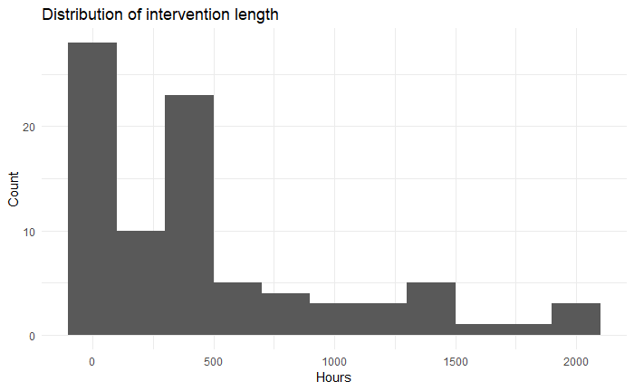

```r
plot <- effects_evaluations %>%
  select(evaluation_id, length_intervention) %>%
  distinct() %>%
  ggplot(data = ., aes(length_intervention))+
  geom_histogram(binwidth = 200)+
  labs(title = "Distribution of intervention length",
       x = "Hours", y = "Count")+
  theme_minimal()

plot
```

We modify categories, not including job-readiness since it is always part of technical o soft training.

```r
effects_evaluations <- effects_evaluations %>%
  mutate(skills= recode(skills,soft="Soft",technical="Technical",both="Both",
                        "technical, job-readniess"= "Technical",
                        "soft, job-readiness"= "Soft"),
         training=recode(training,both="Both",classroom="Classroom", "some class, some OJT" = NA_character_),
         where_internship=recode(where_internship,"private-subsidized"="Private-subsidized",
                                 "private subsidized" = "Private-subsidized",
                                 private="Private"),
         where_class=recode(where_class,public="Public",private="Private",
                            "public, private" = "Public - Private"),
         implementer=as.character(implementer),
        implementer=replace(implementer, implementer=="Multilateral","Mulilateral_NGO"),
        implementer=replace(implementer, implementer=="NGO","Mulilateral_NGO"))
```

```r
count(effects_evaluations, where_class)
```

```
Grouping rowwise data frame strips rowwise natureFactor `where_class` contains implicit NA, consider using `forcats::fct_explicit_na`
```

| where_class | n |
| --- | --- |
| Private | 640 |
| Public | 127 |
| Public - Private | 227 |
| NA | 277 |

Ordering for the forest plot subgroups

```r
effects_evaluations<-effects_evaluations %>%
  mutate(skills_order=recode(skills,Soft=1, Technical=2, Both=3),
         )
```

#Save file as RDS

Now, we save the file to be used in following steps

```r
saveRDS(effects_evaluations, file = here("data","cleanDatafile.rds"))
```